# Lab 12: Beyond the General Linear Model

Johanna Ravenhurst

2022-12-10

I didn’t work with other students.

```r
#Setup
rm(list = ls())
require(here)
birds   = read.csv(here("data", "bird.sub.csv"))
hab     = read.csv(here("data", "hab.sub.csv"))
birdhab = merge(
  birds,
  hab, by=c("basin", "sub"))
```

#I need the functions and linear model from Lab 11 in order to re-create the sample size simulation at the beginning of the walkthrough

```r
#functions from Lab 11
linear_simulator = function(x, y_int, slope, st_dev)
{
  y_det = y_int + slope * x
  output_sim = rnorm(n = length(x), mean = y_det, sd = st_dev)
  return (output_sim)
}

#function for simulation loops
linear_sim_fit = function(x, slope, y_int, st_dev)
{
  y_sim = linear_simulator(
    x = x,
    y_int = y_int,
    slope = slope,
    st_dev = st_dev
  )
  fit_sim = lm(y_sim ~ x)
  return(fit_sim)
}
```

```r
#Fit simple linear regression
fit_1 = lm(BRCR ~ ls, data = birdhab)

#Retrieve the model coefficients
fit_1_coefs = coefficients(fit_1)
str(fit_1_coefs)
```

```
##  Named num [1:2] 0.0991 0.00584
##  - attr(*, "names")= chr [1:2] "(Intercept)" "ls"
```

```r
#Retrieve the standard deviation parameter

fit_1_summary = summary(fit_1)
str(fit_1_summary)
```

```
## List of 11
##  $ call         : language lm(formula = BRCR ~ ls, data = birdhab)
##  $ terms        :Classes 'terms', 'formula'  language BRCR ~ ls
##   .. ..- attr(*, "variables")= language list(BRCR, ls)
##   .. ..- attr(*, "factors")= int [1:2, 1] 0 1
##   .. .. ..- attr(*, "dimnames")=List of 2
##   .. .. .. ..$ : chr [1:2] "BRCR" "ls"
##   .. .. .. ..$ : chr "ls"
##   .. ..- attr(*, "term.labels")= chr "ls"
##   .. ..- attr(*, "order")= int 1
##   .. ..- attr(*, "intercept")= int 1
##   .. ..- attr(*, "response")= int 1
##   .. ..- attr(*, ".Environment")=<environment: R_GlobalEnv>
##   .. ..- attr(*, "predvars")= language list(BRCR, ls)
##   .. ..- attr(*, "dataClasses")= Named chr [1:2] "numeric" "numeric"
##   .. .. ..- attr(*, "names")= chr [1:2] "BRCR" "ls"
##  $ residuals    : Named num [1:30] -0.0747 -0.1297 0.0256 0.1255 0.1009 ...
##   ..- attr(*, "names")= chr [1:30] "1" "2" "3" "4" ...
##  $ coefficients : num [1:2, 1:4] 0.099104 0.00584 0.050764 0.000871 1.952266 ...
##   ..- attr(*, "dimnames")=List of 2
##   .. ..$ : chr [1:2] "(Intercept)" "ls"
##   .. ..$ : chr [1:4] "Estimate" "Std. Error" "t value" "Pr(>|t|)"
##  $ aliased      : Named logi [1:2] FALSE FALSE
##   ..- attr(*, "names")= chr [1:2] "(Intercept)" "ls"
##  $ sigma        : num 0.141
##  $ df           : int [1:3] 2 28 2
##  $ r.squared    : num 0.616
##  $ adj.r.squared: num 0.602
##  $ fstatistic   : Named num [1:3] 45 1 28
##   ..- attr(*, "names")= chr [1:3] "value" "numdf" "dendf"
##  $ cov.unscaled : num [1:2, 1:2] 0.129129 -0.001909 -0.001909 0.000038
##   ..- attr(*, "dimnames")=List of 2
##   .. ..$ : chr [1:2] "(Intercept)" "ls"
##   .. ..$ : chr [1:2] "(Intercept)" "ls"
##  - attr(*, "class")= chr "summary.lm"
```

```r
fit_1_summary$sigma
```

```
## [1] 0.1412668
```

```r
#Store the intercept, slope, and standard deviation parameters from the model into the following variables:
int_obs <- fit_1_coefs["(Intercept)"]
slope_obs <- fit_1_coefs["ls"]
sd_obs <- fit_1_summary$sigma
```

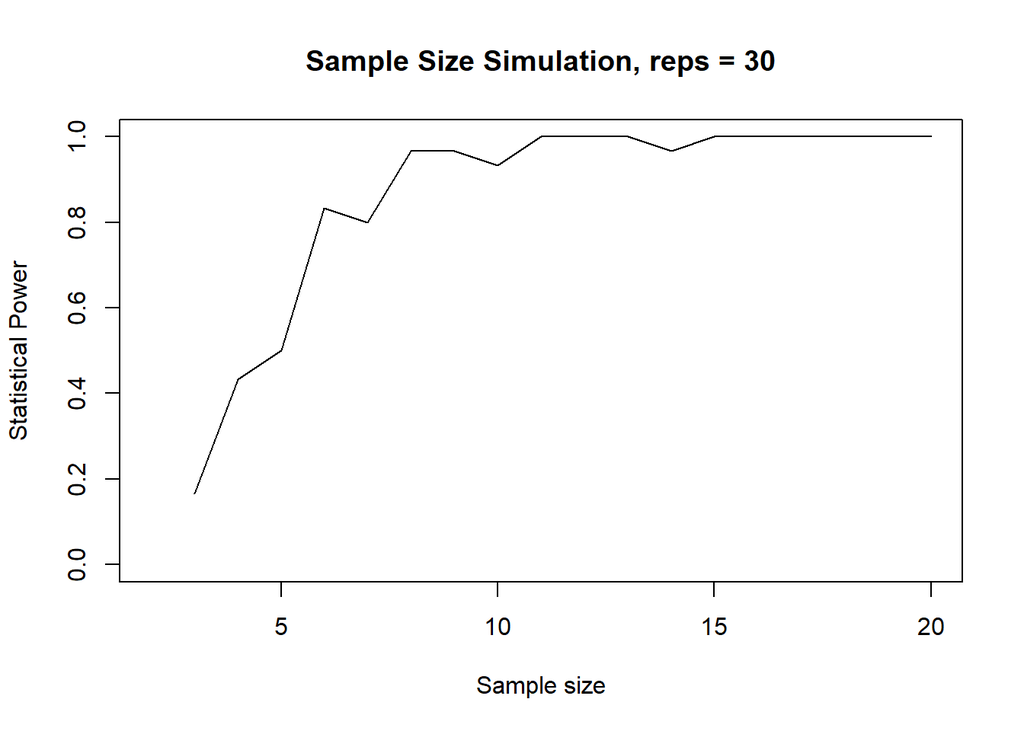

```r
alpha = 0.05
n_sims = 30
p_vals = numeric(n_sims)

sample_sizes = seq(2, 20)
sample_size_powers = numeric(length(sample_sizes))

# The maximum x value in the simulation.
# Use the maximum observed x-value in the data
max_x = max(birdhab$ls)

for(j in 1:length(sample_sizes))
{
  # A sequence of equally-spaced x-values:
  x_vals = seq(0, max_x, length.out = sample_sizes[j])

  for(i in 1:n_sims)
  {
    fit_sim = linear_sim_fit(
      x = x_vals,
      y_int = int_obs,
      slope = slope_obs,
      st_dev = sd_obs
    )
    p_vals[i] = summary(fit_sim)$coefficients[2, 'Pr(>|t|)']
  }
  sample_size_powers[j] = sum(p_vals < alpha) / n_sims
}


sim_sample_size =
  data.frame(
    sample_size = sample_sizes,
    power       = sample_size_powers)


plot(
  power ~ sample_size, data = sim_sample_size,
  type = 'l',
  main = "Sample Size Simulation, reps = 30",
  xlab = 'Sample size',
  ylab = 'Statistical Power',
  ylim = c(0, 1.0))
```

# **Q1: Fitting a LOWESS Model**

**Q1 (2 pts.): Include your plot in your lab report.**

```r
fit_lowess_30 = loess(power ~ sample_size, data = sim_sample_size, span = 0.3)
str(fit_lowess_30)
```

```
## List of 19
##  $ n        : int 18
##  $ fitted   : num [1:18] 0.183 0.373 0.5 0.833 0.8 ...
##  $ residuals: Named num [1:18] -1.61e-02 6.07e-02 5.55e-17 -1.11e-16 -1.11e-16 ...
##   ..- attr(*, "names")= chr [1:18] "2" "3" "4" "5" ...
##  $ enp      : num 16.4
##  $ s        : num 0.259
##  $ one.delta: num 0.0587
##  $ two.delta: num -0.302
##  $ trace.hat: num 17.2
##  $ divisor  : num 1
##  $ robust   : num [1:18] 1 1 1 1 1 1 1 1 1 1 ...
##  $ pars     :List of 10
##   ..$ span       : num 0.3
##   ..$ degree     : int 2
##   ..$ normalize  : logi TRUE
##   ..$ parametric : logi FALSE
##   ..$ drop.square: logi FALSE
##   ..$ surface    : chr "interpolate"
##   ..$ cell       : num 0.2
##   ..$ family     : chr "gaussian"
##   ..$ trace.hat  : chr "exact"
##   ..$ iterations : int 1
##  $ kd       :List of 5
##   ..$ parameter: Named int [1:7] 1 18 2 35 19 1049 849
##   .. ..- attr(*, "names")= chr [1:7] "d" "n" "vc" "nc" ...
##   ..$ a        : int [1:35] 1 1 1 1 1 1 1 1 1 1 ...
##   ..$ xi       : num [1:35] 11 7 16 5 9 14 18 4 6 8 ...
##   ..$ vert     : num [1:2] 2.92 20.09
##   ..$ vval     : num [1:38] 1.65e-01 2.09e-01 1.00 2.08e-16 1.00 ...
##  $ call     : language loess(formula = power ~ sample_size, data = sim_sample_size, span = 0.3)
##  $ terms    :Classes 'terms', 'formula'  language power ~ sample_size
##   .. ..- attr(*, "variables")= language list(power, sample_size)
##   .. ..- attr(*, "factors")= int [1:2, 1] 0 1
##   .. .. ..- attr(*, "dimnames")=List of 2
##   .. .. .. ..$ : chr [1:2] "power" "sample_size"
##   .. .. .. ..$ : chr "sample_size"
##   .. ..- attr(*, "term.labels")= chr "sample_size"
##   .. ..- attr(*, "order")= int 1
##   .. ..- attr(*, "intercept")= int 1
##   .. ..- attr(*, "response")= int 1
##   .. ..- attr(*, ".Environment")=<environment: R_GlobalEnv>
##   .. ..- attr(*, "predvars")= language list(power, sample_size)
##   .. ..- attr(*, "dataClasses")= Named chr [1:2] "numeric" "numeric"
##   .. .. ..- attr(*, "names")= chr [1:2] "power" "sample_size"
##  $ xnames   : Named chr "sample_size"
##   ..- attr(*, "names")= chr "sample_size"
##  $ x        : int [1:18, 1] 3 4 5 6 7 8 9 10 11 12 ...
##   ..- attr(*, "dimnames")=List of 2
##   .. ..$ : chr [1:18] "2" "3" "4" "5" ...
##   .. ..$ : chr "sample_size"
##  $ y        : Named num [1:18] 0.167 0.433 0.5 0.833 0.8 ...
##   ..- attr(*, "names")= chr [1:18] "2" "3" "4" "5" ...
##  $ weights  : num [1:18] 1 1 1 1 1 1 1 1 1 1 ...
##  $ na.action: 'omit' Named int 1
##   ..- attr(*, "names")= chr "1"
##  - attr(*, "class")= chr "loess"
```

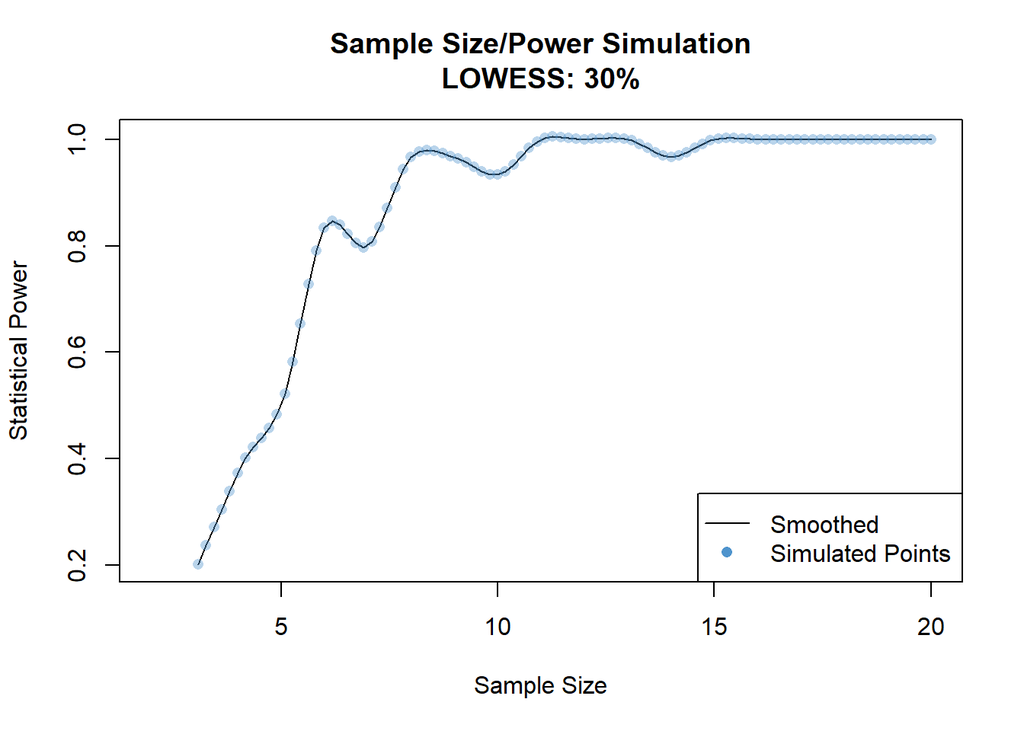

```r
newdata_sample_size = data.frame(sample_size = seq(2, 20, length.out = 100))

{
plot(
  x = newdata_sample_size$sample_size,
  y = predict(fit_lowess_30, newdata = newdata_sample_size),
  type = "l",
  main = "Sample Size/Power Simulation\nLOWESS: 30%",
  ylab = "Statistical Power", xlab = "Sample Size")

points(newdata_sample_size$sample_size, predict(fit_lowess_30, newdata = newdata_sample_size), col = adjustcolor(col = "steelblue3", alpha.f = .4), pch = 16)

legend(
  x="bottomright",
  bty="o", border = "black",
  legend=c('Smoothed', 'Simulated Points'),
  col=c("black", "steelblue3"), inset=c(0,0), lty = c(1, NA), pch = c(NA, 16))
}
```

# Nonlinear Least Squares

# **Q2: Nonlinear Least Squares**

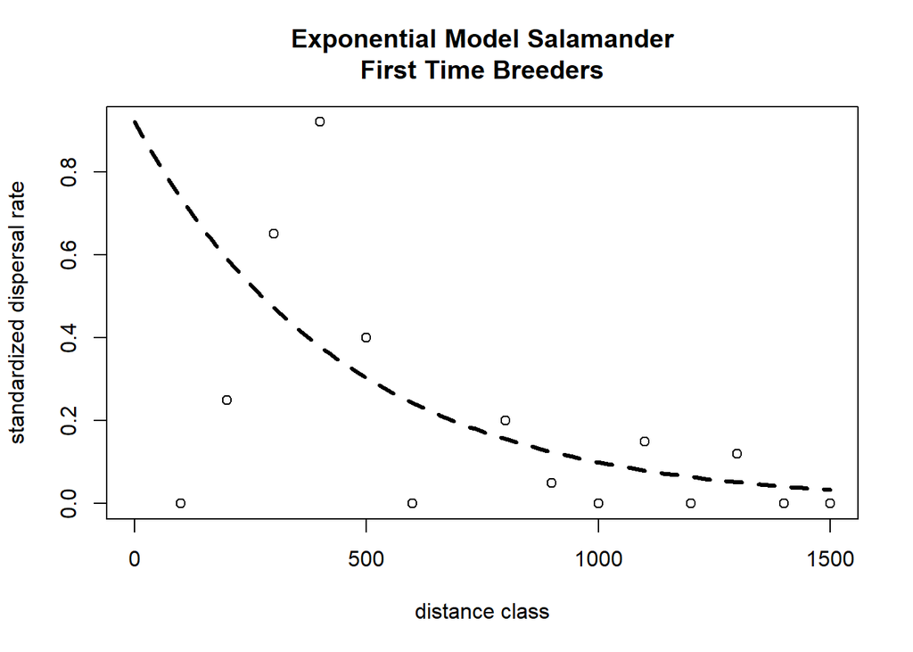

```r
#Setup code - read in data, exponential model code from Lab 5

dat_dispersal <- read.csv(here("data", "dispersal.csv"))
#str(dat_dispersal)

exp_fun = function(x, a, b)
{
  return(a * exp(-b * x))
}

 #Exponential Model from Lab 5 - explanation of values I picked for visual estimation

 #a=0.92
 #b=1/500
 #I chose the value for a by using the summary function for the data frame and then selecting the maximum value for standardized dispersal rate. I think this makes sense because a is supposed to be the highest point of the exponential curve. In order to find a potential value for b, I calculated a/e = 0.92/e = 0.338. This is the y value at the point where 1/b is equal to the corresponding x value for the exponential curve. When I look at the scatterplot when y is 0.4, I'm guessing that the x value for the fitted exponential curve should be around 450, so 450 = 1/b, which means b=1/450.

plot(dat_dispersal$dist.class,
    dat_dispersal$disp.rate.ftb,
    xlim = c(0, 1500),
     main = "Exponential Model Salamander\nFirst Time Breeders",
     xlab = "distance class", ylab = "standardized dispersal rate")

 curve(
  exp_fun(x, 0.92, 1/450),
  from = 0, to = 1500, add = TRUE,
  ylim = c (0, 1),
  col = "black", type = "l", lty = 2, lwd = 3)
```

**Q2 - Plot of NLS exponential model and visually-fitted exponential model from Lab 5**

```r
fit_exp_nls = nls(
  disp.rate.ftb ~ exp_fun(dist.class, a, b),
  data = dat_dispersal,
  start = list(b = 0, a = 1))
summary(fit_exp_nls)
```

```
##
## Formula: disp.rate.ftb ~ exp_fun(dist.class, a, b)
##
## Parameters:
##    Estimate Std. Error t value Pr(>|t|)
## b 0.0011693  0.0008997   1.300   0.2182
## a 0.4640859  0.2238321   2.073   0.0603 .
## ---
## Signif. codes:  0 '***' 0.001 '**' 0.01 '*' 0.05 '.' 0.1 ' ' 1
##
## Residual standard error: 0.2614 on 12 degrees of freedom
##
## Number of iterations to convergence: 19
## Achieved convergence tolerance: 9.031e-06
##   (1 observation deleted due to missingness)
```

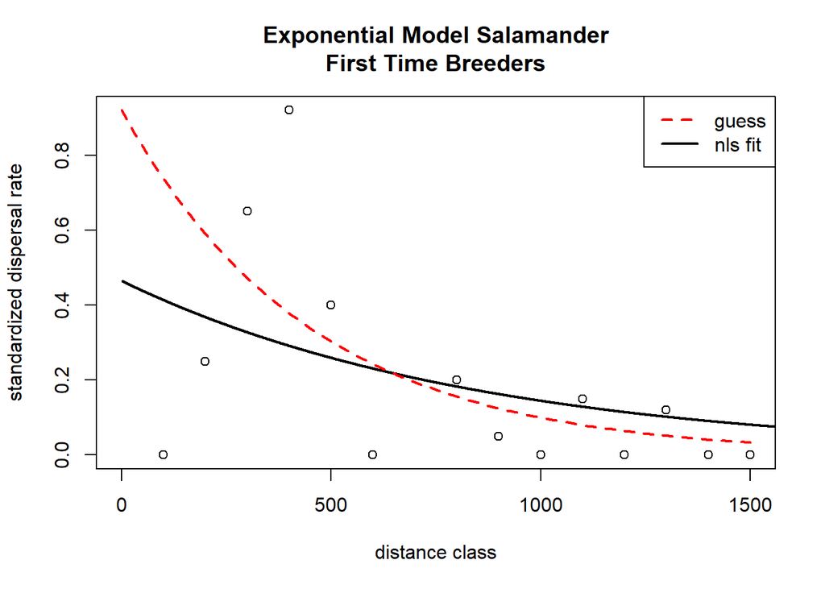

```r
dist_newdata2 = data.frame(dist.class = seq(0, 1600, length.out = 1600))

plot(dat_dispersal$dist.class,
    dat_dispersal$disp.rate.ftb,
    xlim = c(0, 1500),
     main = "Exponential Model Salamander\nFirst Time Breeders",
     xlab = "distance class", ylab = "standardized dispersal rate")
lines(predict(fit_exp_nls, newdata = dist_newdata2), lwd = 2)
 curve(
  exp_fun(x, 0.92, 1/450),
  from = 0, to = 1500, add = TRUE,
  ylim = c (0, 1),
  col = "red", type = "l", lty = 2, lwd = 2)
legend("topright", legend = c("guess", "nls fit"), col=c("red", "black"), lty = c(2, 1), lwd = 2)
```

#Logistic Regression (walkthrough code for HEWA not included in output)

```r
#setup
dat_bird = read.csv(here("data", "bird.sta.csv"))
dat_habitat = read.csv(here("data", "hab.sta.csv"))
dat_all = merge(dat_bird, dat_habitat)
```

#Plotting a fitted simple logistic model (walkthrough)

#Plotting the models

#Plotting both parameters

#Contour plot

# **Q3-5: Logistic Models 1: Model Fits**

```r
#Fit four logistic models of golden crowned kinglet (GCKI) presence/absence

#hermit warblers - convert to presence/absence
dat_all$GCKI_pres = dat_all$GCKI > 0


# Create model fits
#family = binomial tells glm () that we want to do logistic regression
fit_gcki_slope = glm(GCKI_pres ~ slope, data = dat_all, family = binomial)
fit_gcki_ba_tot = glm(GCKI_pres ~ ba.tot, data = dat_all, family = binomial)
fit_gcki_both_additive = glm(GCKI_pres ~ slope + ba.tot, data = dat_all, family = binomial)
fit_gcki_both_interactive = glm(GCKI_pres ~ slope * ba.tot, data = dat_all, family = binomial)
```

**Q3 (1 pt.): What are the AIC values for each of the 4 models?**

```r
#compare models using AIC:
AIC(
  fit_gcki_ba_tot,
  fit_gcki_slope,
  fit_gcki_both_additive,
  fit_gcki_both_interactive)
```

```
##                           df      AIC
## fit_gcki_ba_tot            2 1369.379
## fit_gcki_slope             2 1432.615
## fit_gcki_both_additive     3 1355.951
## fit_gcki_both_interactive  4 1353.007
```

**Q4 (1 pt.): Which model would you choose, and why?**

I would chose the interactive model because it has the lowest AIC value. Having the lowest AIC value means that this model does the best job explaining the variation in the data.

**Q5 (1 pt.): Based on the model coefficient table of your chosen model, describe the direction and significance of the relationship(s) of the predictor variable or variables to the binary response. Make sure your answer is in terms of the ecological context.**

The model coefficient table shows that the slope coefficient is not a significant predictor of golden crowned kinglet on its own (based on the high p-value of 0.3674), but the interaction of slope and total basal area is a significant negative predictor (coefficient = -0.0004, p-value = 0.0269). For every one-unit increase in the interaction between slope and total basal area, there is a 0.0004 decrease in probability of presence of golden crowned kinglet.

The total basal area on its own is a significant positive predictor (coefficient = 0.0533, p-value = <0.0001). For every one-unit increase in total basal area, there is a significant increase of 0.053 probability of presence of golden crowned kinglet.

```r
summary(fit_gcki_both_interactive)
```

```
##
## Call:
## glm(formula = GCKI_pres ~ slope * ba.tot, family = binomial,
##     data = dat_all)
##
## Deviance Residuals:
##     Min       1Q   Median       3Q      Max
## -3.7433  -1.0717   0.6444   1.0862   1.4846
##
## Coefficients:
##                Estimate Std. Error z value Pr(>|z|)
## (Intercept)  -0.2643673  0.2500615  -1.057   0.2904
## slope        -0.0040863  0.0045338  -0.901   0.3674
## ba.tot        0.0532974  0.0109776   4.855  1.2e-06 ***
## slope:ba.tot -0.0004131  0.0001866  -2.214   0.0269 *
## ---
## Signif. codes:  0 '***' 0.001 '**' 0.01 '*' 0.05 '.' 0.1 ' ' 1
##
## (Dispersion parameter for binomial family taken to be 1)
##
##     Null deviance: 1439.7  on 1045  degrees of freedom
## Residual deviance: 1345.0  on 1042  degrees of freedom
## AIC: 1353
##
## Number of Fisher Scoring iterations: 4
```

# **Q6-7: Logistic Models 2: Graphical Exploration**

**Q6 (2 pts.): Include your two single-predictor model plots in your report.**

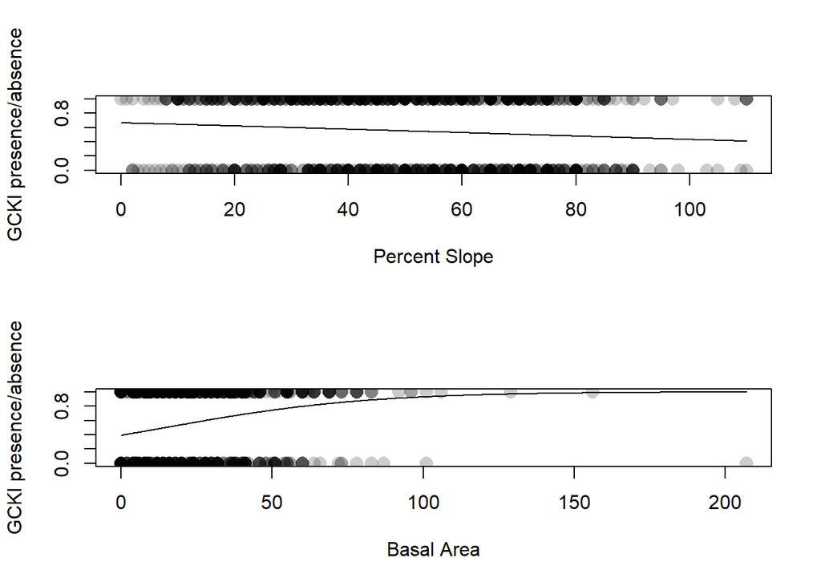

```r
#make a data.frame object with a sequence of 500 new slopes
#use min/max slopes from observed data and use na.rm to deal with missing data
n = 500

slope_newdata = data.frame(
  slope = seq(
    from = min(dat_all$slope, na.rm = T),
    to = max(dat_all$slope, na.rm = T),
    length.out = n
  )
)

#make a data.frame object of total basal area values for prediction
n = 500

ba_newdata = data.frame(
  ba.tot = seq(
    from = min(dat_all$ba.tot, na.rm = T),
    to = max(dat_all$ba.tot, na.rm = T),
    length.out = n
  )
)

#predictions - predicted values are new columns in the data frame objects
# type = "response" so the predicted values are on the scale of probability

slope_newdata$gcki_predicted =
  predict(
    fit_gcki_slope,
    newdata = slope_newdata,
    type = "response"
  )

ba_newdata$gcki_predicted =
  predict(
    fit_gcki_ba_tot,
    newdata = ba_newdata,
    type = "response"
  )

par(mfrow = c(2, 1))

# Presence/absence data, translucent points:
plot(
  GCKI_pres ~ slope, data = dat_all,
  xlab = "Percent Slope",
  ylab = "GCKI presence/absence",
  pch = 16, cex = 1.5, col = gray(0, 0.2)
)

lines(gcki_predicted ~ slope, data = slope_newdata)

plot(
  GCKI_pres ~ ba.tot, data = dat_all,
  xlab = "Basal Area",
  ylab = "GCKI presence/absence",
  pch = 16, cex = 1.5, col = gray(0, 0.2)
)

lines(gcki_predicted ~ ba.tot, data = ba_newdata)
```

**Q7 (4 pts.): Include contour plots (or interactive 3D perspective plots) in your report.**

```r
#data setup - need dataframe with columns for both predictors (total basal area and slope)
#create sequences of values for both predictors:
n = 50

ba.tot = seq(
  from = min(dat_all$ba.tot, na.rm = T),
  to = max(dat_all$ba.tot, na.rm = T),
  length.out = n)
slope = seq(
  from = min(dat_all$slope, na.rm = T),
  to = max(dat_all$slope, na.rm = T),
  length.out = n)

#use expand.grid() to make a data frame with every combination of the two predictors
new_dat_all = expand.grid(
  ba.tot = ba.tot,
  slope = slope)
head(new_dat_all)
```

```
##     ba.tot slope
## 1  0.00000     0
## 2  4.22449     0
## 3  8.44898     0
## 4 12.67347     0
## 5 16.89796     0
## 6 21.12245     0
```

```r
tail(new_dat_all)
```

```
##        ba.tot slope
## 2495 185.8776   110
## 2496 190.1020   110
## 2497 194.3265   110
## 2498 198.5510   110
## 2499 202.7755   110
## 2500 207.0000   110
```

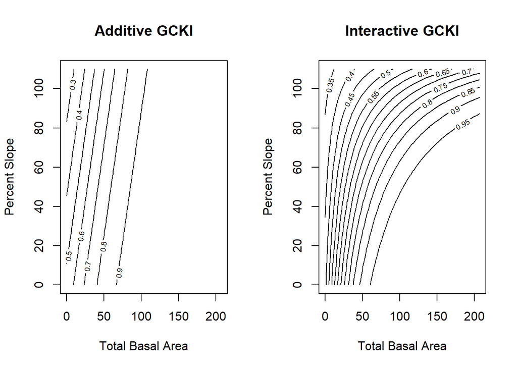

```r
#use predict to make a vector of model predictions:
new_dat_all$pred_add_gcki = predict(
  fit_gcki_both_additive,
  newdata = new_dat_all,
  type = "response")

new_dat_all$pred_int_gcki = predict(
  fit_gcki_both_interactive,
  newdata = new_dat_all,
  type = "response")

#need matrices for data on the z-axis

z_gcki_add = matrix(
  new_dat_all$pred_add_gcki,
  nrow = length(ba.tot),
  byrow = FALSE)
z_gcki_int = matrix(
  new_dat_all$pred_int_gcki,
  nrow = length(ba.tot),
  byrow = FALSE)

par(mfrow = c(1, 2))
contour(
  x = ba.tot, y = slope,
  z = z_gcki_add,
  xlab = "Total Basal Area",
  ylab = "Percent Slope",
  main = "Additive GCKI")
contour(
  x = ba.tot,
  y = slope,
  z = z_gcki_int,
  xlab = "Total Basal Area",
  ylab = "Percent Slope",
  main = "Interactive GCKI")
```